## Prerequisites

```r
library(ggplot2)
```

## Loading and preprocessing the data

```r
if(!file.exists('activity.csv')){
    unzip('activity.zip')
}
activity <- read.csv('activity.csv')
activity$date <- as.POSIXct(activity$date)
```

## What is mean total number of steps taken per day?

### Calculate the total number of steps taken per day

```r
totalStepsByDay <- aggregate(activity$steps, by = list(activity$date), sum, na.rm=TRUE)
names(totalStepsByDay) <- c("Date", "Steps")
```

### Make a histogram of the total number of steps taken each day

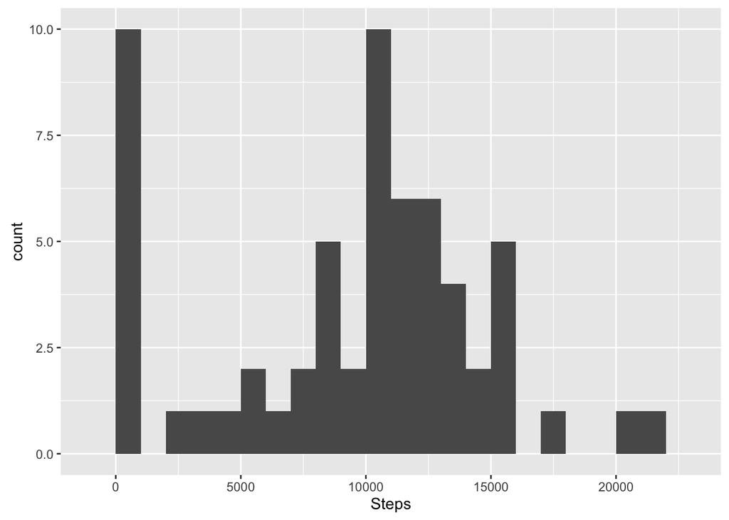

```r
ggplot(totalStepsByDay, aes(x = Steps)) +
            geom_histogram(binwidth = 1000)
```

### Calculate and report the mean and median of the total number of steps taken per day

```r
stepsMean <- mean(totalStepsByDay$Steps)
stepsMedian <- median(totalStepsByDay$Steps)

stepsMean
```

```
## [1] 9354.23
```

```r
stepsMedian
```

```
## [1] 10395
```

## What is the average daily activity pattern?

### Make a time series plot of the 5-minute interval (x-axis) and the average number of steps taken, averaged across all days (y-axis)

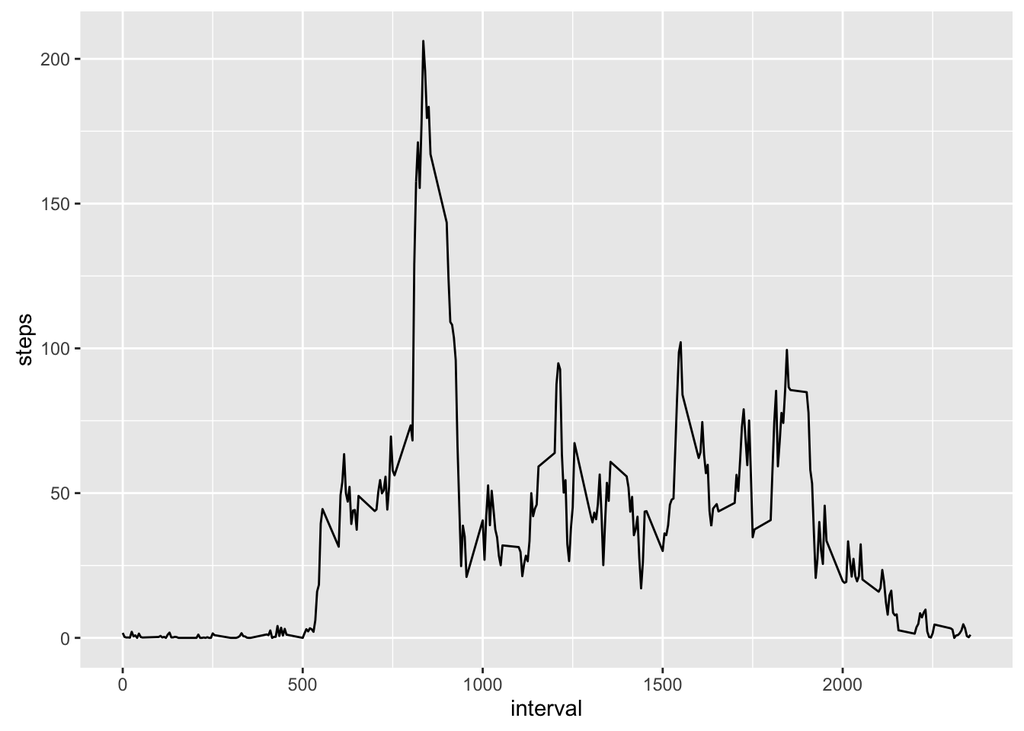

```r
avgStepsByInterval <- aggregate(x= activity$steps, by=list(activity$interval), FUN=mean, na.rm=TRUE)
names(avgStepsByInterval) <- c("interval", "steps")
ggplot(avgStepsByInterval, aes(interval,steps)) +  geom_line()
```

### Which 5-minute interval, on average across all the days in the dataset, contains the maximum number of steps?

```r
maxStepsInterval <- avgStepsByInterval[which.max(avgStepsByInterval$steps), c("interval")]
maxStepsInterval
```

```
## [1] 835
```

## Imputing missing values

### Calculate and report the total number of missing values in the dataset

```r
numNA <- length(which(is.na(activity$steps)))
numNA
```

```
## [1] 2304
```

Total number of missing values: 2304

### Create a new dataset that is equal to the original dataset but with the missing data filled in.

```r
activityClean <- activity
activityClean$steps[is.na(activityClean$steps)] <- tapply(activityClean$steps, activityClean$interval, FUN = mean, na.rm = TRUE)
```

### Make a histogram of the total number of steps taken each day and Calculate and report the mean and median total number of steps taken per day.

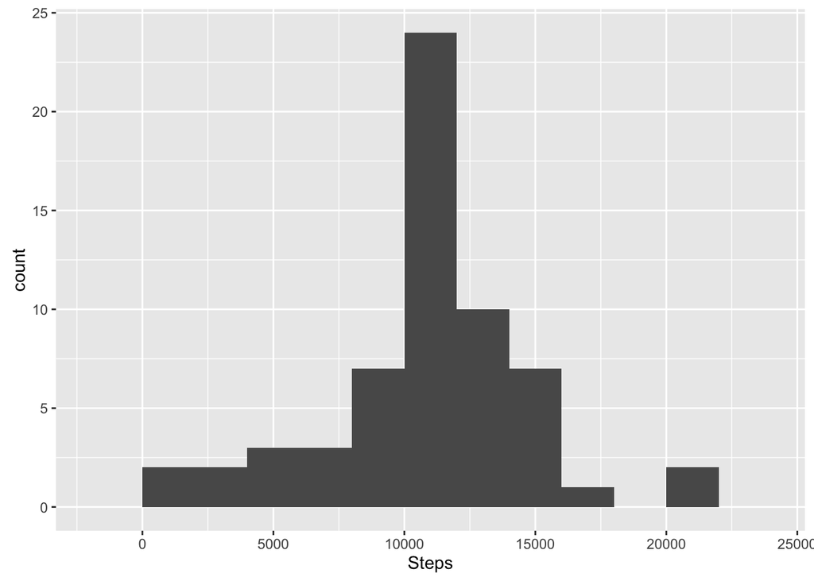

```r
newSteps <- aggregate(x = activityClean$steps , by = list(activityClean$date), FUN = sum)
names(newSteps) <- c("Date", "Steps")
ggplot(newSteps, aes(x = Steps)) +
            geom_histogram(binwidth = 2000)
```

```r
newStepsMean <- mean(newSteps$Steps)
newStepsMedian <- median(newSteps$Steps)
newStepsMean
```

```
## [1] 10766.19
```

```r
newStepsMedian
```

```
## [1] 10766.19
```

Mean: 10766.19 Median: 10766.19

## Are there differences in activity patterns between weekdays and weekends?

### Create a new factor variable in the dataset with two levels – “weekday” and “weekend” indicating whether a given date is a weekday or weekend day.

```r
activityClean$dateType <-  ifelse(as.POSIXlt(activityClean$date)$wday %in% c(0,6), 'weekend', 'weekday')
x <- aggregate(steps ~ interval + dateType, data=activityClean, mean)
```

### Make a panel plot containing a time series plot (i.e. 𝚝𝚢𝚙𝚎 = “𝚕”) of the 5-minute interval (x-axis) and the average number of steps taken, averaged across all weekday days or weekend days (y-axis).

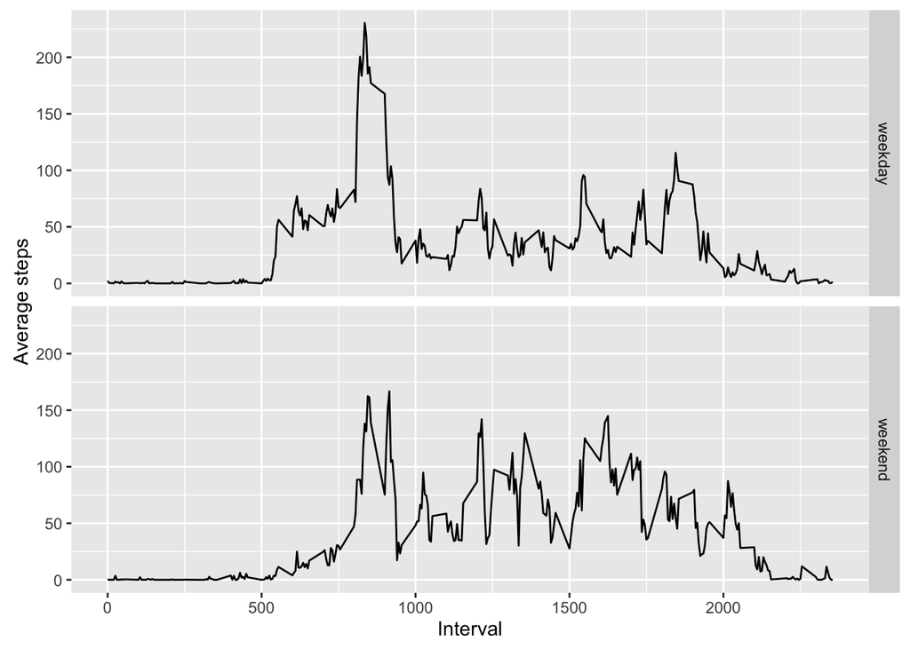

```r
ggplot(x, aes(interval, steps)) +
    geom_line() +
    facet_grid(dateType ~ .) +
    xlab("Interval") +
    ylab("Average steps")
```